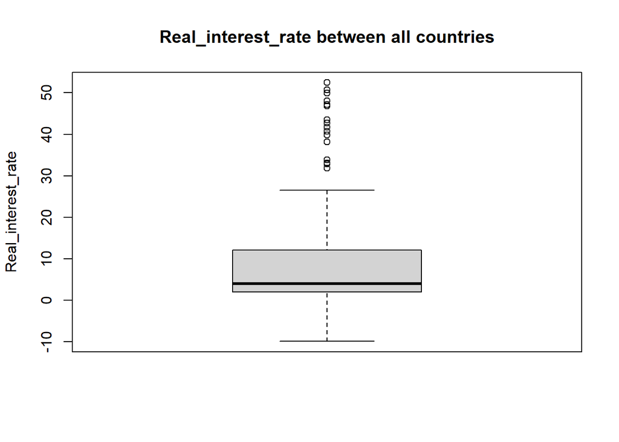

```r
#  boxplot
  boxplot(data$Real_interest_rate_perc, main = "Real_interest_rate between all countries",
        ylab = "Real_interest_rate")
```

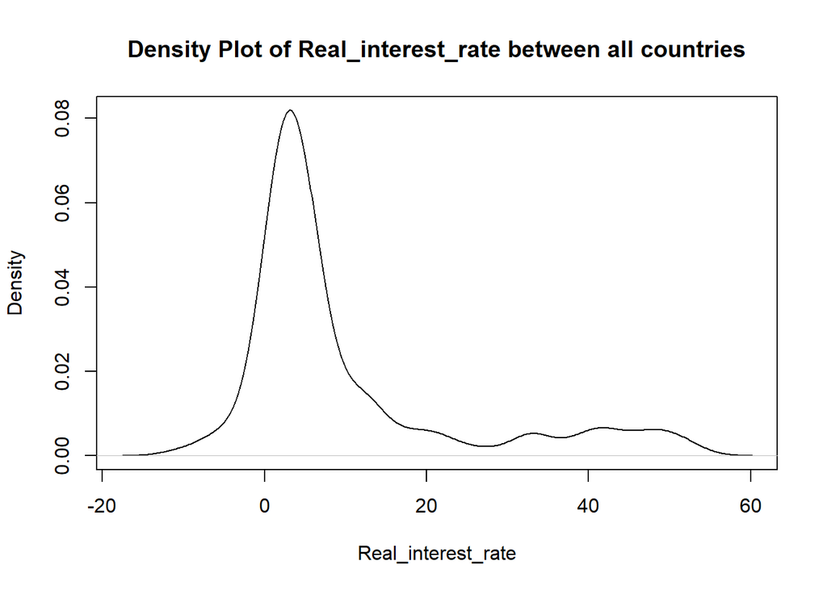

```r
# Create a density plot

plot(density(data$Real_interest_rate_perc), main = "Density Plot of Real_interest_rate between all countries",
     xlab = "Real_interest_rate", ylab = "Density")
```

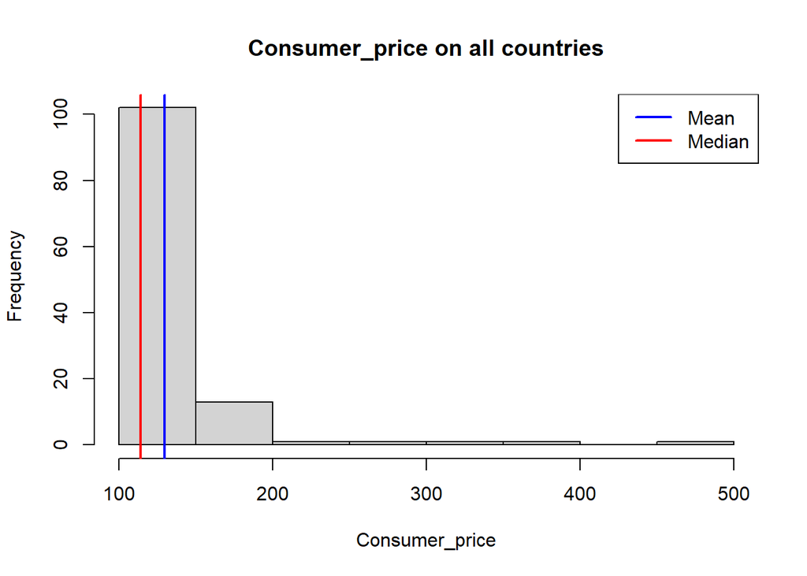

```r
#  histogram with mean, median
hist(data$Consumer_price_index_2010._100, breaks = 8, main = "Consumer_price on all countries",
     xlab = "Consumer_price", ylab = "Frequency")
abline(v = mean(data$Consumer_price_index_2010._100), col = "blue", lwd = 2)
abline(v = median(data$Consumer_price_index_2010._100), col = "red", lwd = 2)
legend("topright", legend = c("Mean", "Median"), col = c("blue", "red"), lwd = 2)
```

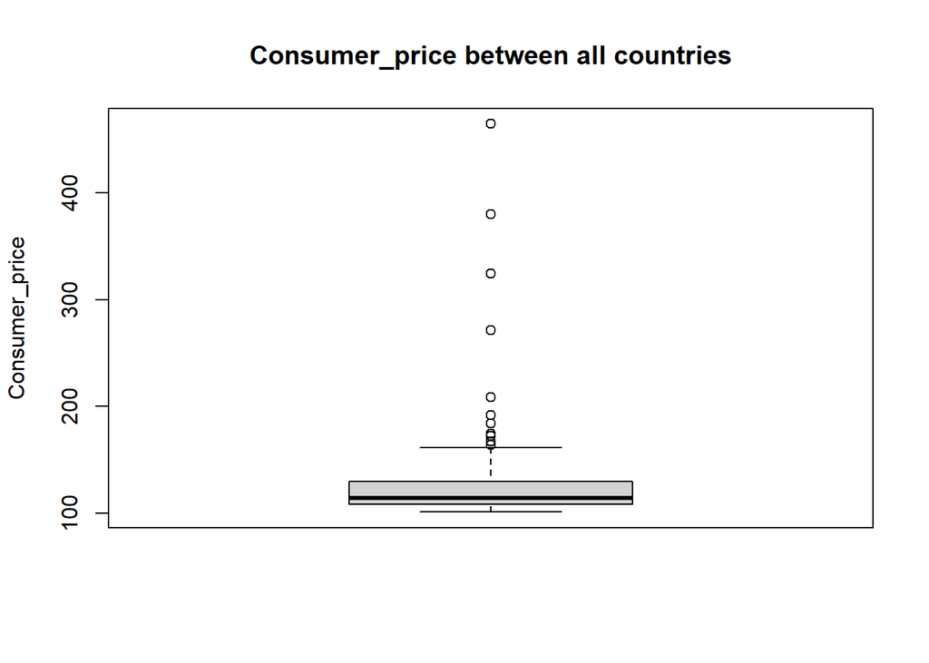

```r
#  boxplot
  boxplot(data$Consumer_price_index_2010._100, main = "Consumer_price between all countries",
        ylab = "Consumer_price")
```

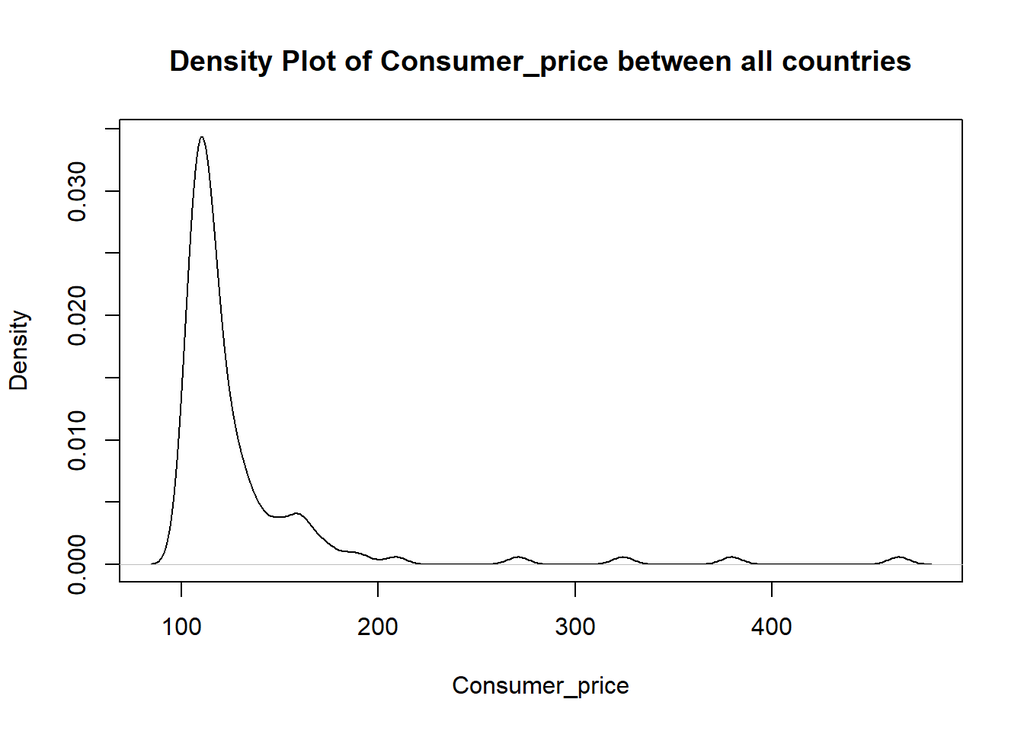

```r
# Create a density plot

plot(density(data$Consumer_price_index_2010._100), main = "Density Plot of Consumer_price between all countries",
     xlab = "Consumer_price", ylab = "Density")
```

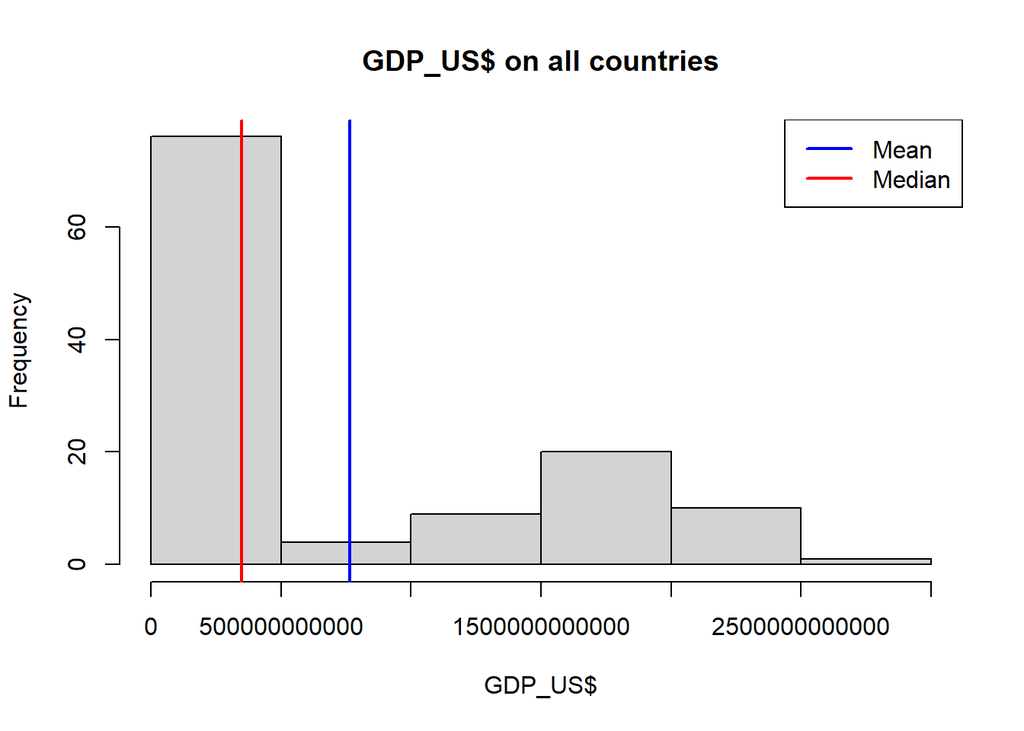

```r
#  histogram with mean, median
  hist(data$GDP_US., breaks = 8, main = "GDP_US$ on all countries",
     xlab = "GDP_US$", ylab = "Frequency")
abline(v = mean(data$GDP_US.), col = "blue", lwd = 2)
abline(v = median(data$GDP_US.), col = "red", lwd = 2)
legend("topright", legend = c("Mean", "Median"), col = c("blue", "red"), lwd = 2)
```

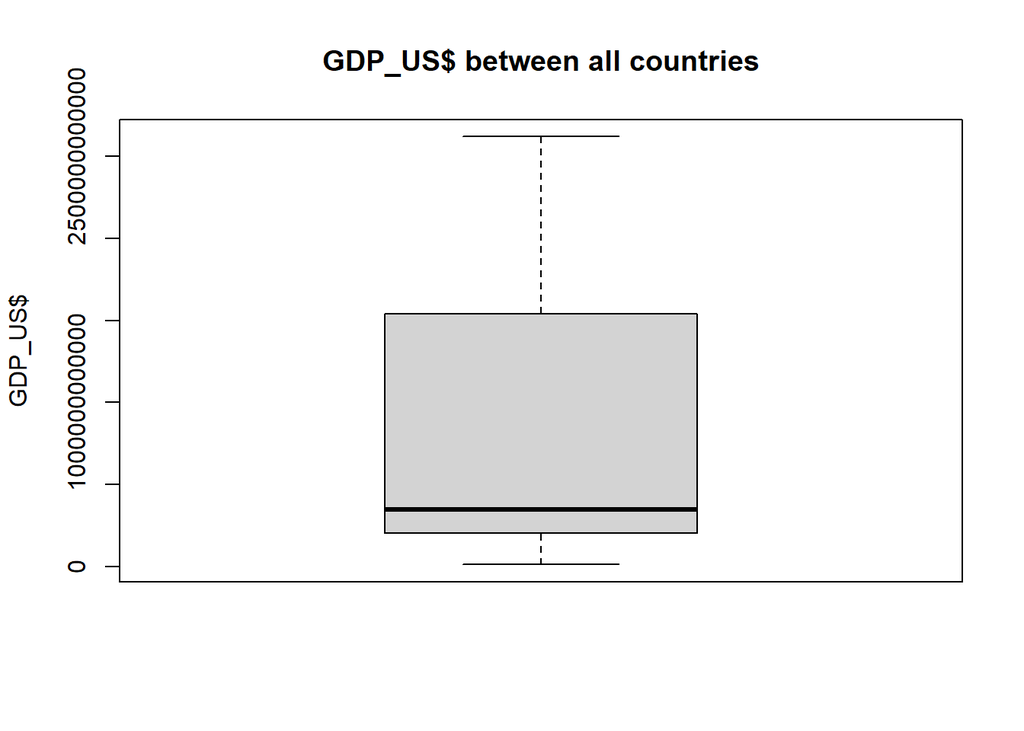

```r
#  boxplot
  boxplot(data$GDP_US., main = "GDP_US$ between all countries",
        ylab = "GDP_US$")
```

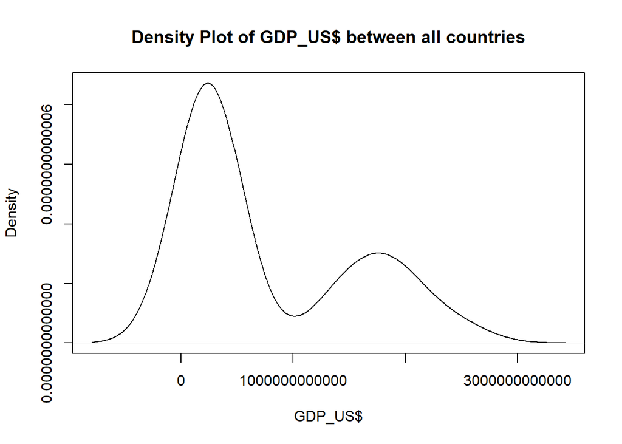

```r
# Create a density plot

plot(density(data$GDP_US.), main = "Density Plot of GDP_US$ between all countries",
     xlab = "GDP_US$", ylab = "Density")
```

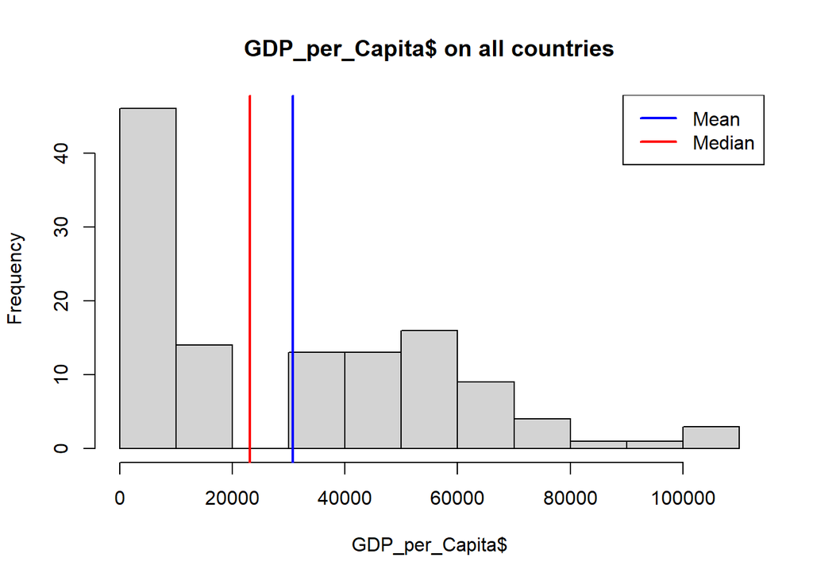

```r
#  histogram with mean, median
  hist(data$GDP_per_Capita, breaks = 8, main = "GDP_per_Capita$ on all countries",
     xlab = "GDP_per_Capita$", ylab = "Frequency")
abline(v = mean(data$GDP_per_Capita), col = "blue", lwd = 2)
abline(v = median(data$GDP_per_Capita), col = "red", lwd = 2)
legend("topright", legend = c("Mean", "Median"), col = c("blue", "red"), lwd = 2)
```

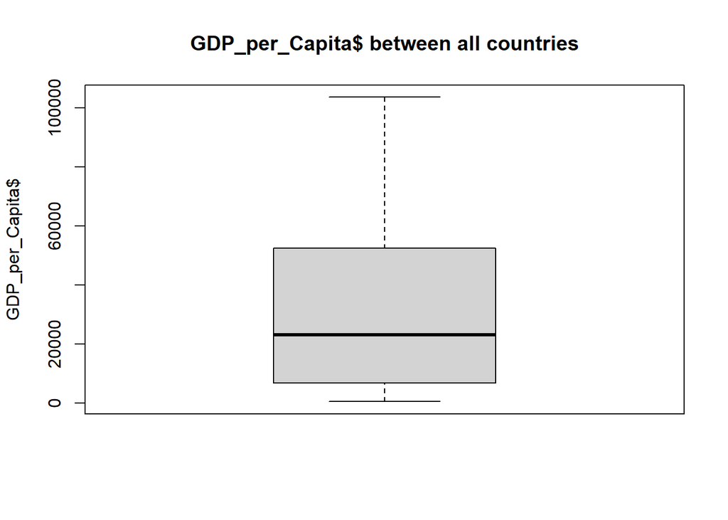

```r
#  boxplot
  boxplot(data$GDP_per_Capita, main = "GDP_per_Capita$ between all countries",
        ylab = "GDP_per_Capita$")
```

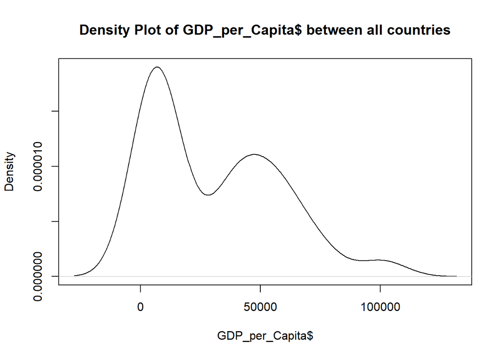

```r
# Create a density plot

plot(density(data$GDP_per_Capita), main = "Density Plot of GDP_per_Capita$ between all countries",
     xlab = "GDP_per_Capita$", ylab = "Density")
```

```r
summary(developing_countries)
```

```
##  Country_Name       Country_Code            Time
##  Length:60          Length:60          Min.   :2011.0
##  Class :character   Class :character   1st Qu.:2013.0
##  Mode  :character   Mode  :character   Median :2015.5
##                                        Mean   :2015.5
##                                        3rd Qu.:2018.0
##                                        Max.   :2020.0
##  Access_to_electricity._percentage_of_pop Life_expectancy_at_birth
##  Min.   : 12.900000000000000              Min.   :57.595999999999997
##  1st Qu.: 41.946258544999999              1st Qu.:63.531500000000001
##  Median : 89.853745500000002              Median :69.759000000000000
##  Mean   : 73.832578725199994              Mean   :69.728383333300002
##  3rd Qu.: 99.612561749999998              3rd Qu.:75.408749999999998
##  Max.   :100.000000000000000              Max.   :80.349999999999994
##  Mortality_rate_under_5_per_1.000_live_births
##  Min.   :  6.9000000000000004
##  1st Qu.: 15.2750000000000004
##  Median : 26.3500000000000014
##  Mean   : 38.9166666667000030
##  3rd Qu.: 66.0999999999999943
##  Max.   :112.2000000000000028
##  Political_Stability.Absence_of_Violence.Terrorism._Percentile_R
##  Min.   :19.431280139999998
##  1st Qu.:30.238095285000000
##  Median :34.988374710000002
##  Mean   :37.446845627000002
##  3rd Qu.:42.200135232500003
##  Max.   :62.085308070000004
##  Population_total         Real_interest_rate_perc
##  Min.   : 17173573.0000   Min.   :-9.8763568409999998
##  1st Qu.: 24702961.7500   1st Qu.: 3.4474823076200001
##  Median : 30281289.5000   Median :12.1359710799999991
##  Mean   : 60806636.2667   Mean   :16.7019267159000009
##  3rd Qu.: 56012946.5000   3rd Qu.:32.1356694400000009
##  Max.   :213196304.0000   Max.   :52.4367881499999982
##  Consumer_price_index_2010._100    GDP_US.
##  Min.   :103.34121690000001     Min.   :  11323020700.000000
##  1st Qu.:117.00814687499999     1st Qu.:  84862711406.800003
##  Median :130.10890135000000     Median : 235000000000.000000
##  Mean   :149.17119826699999     Mean   : 508345289645.000000
##  3rd Qu.:156.48549962499999     3rd Qu.: 383000000000.000000
##  Max.   :464.14168699999999     Max.   :2620000000000.000000
##  GDP_per_Capita
##  Min.   :  455.63803453200001
##  1st Qu.: 2947.49826287999986
##  Median : 6683.70001518000026
##  Mean   : 7006.42622959999971
##  3rd Qu.: 9321.67265315999975
##  Max.   :15819.59945569999945
```

**I will do more in depht descriptive statistic on GPD for developed and developing countries:**

*developing countries stats GPD*

```r
print('developing countries stat for GPD')
```

```
## [1] "developing countries stat for GPD"
```

```r
print(paste('mean in GPS$',mean(developing_countries$GDP_US.)))
```

```
## [1] "mean in GPS$ 508345289644.65"
```

```r
print(paste('median in  GPS$',median(developing_countries$GDP_US.)))
```

```
## [1] "median in  GPS$ 235000000000"
```

```r
print(paste('mode in GPS$', mean(as.numeric(names(sort(table(developing_countries$GDP_US.), decreasing = TRUE)[1])))))
```

```
## [1] "mode in GPS$ 201000000000"
```

```r
print(paste('standars dev in GPS$',sd(developing_countries$GDP_US.)))
```

```
## [1] "standars dev in GPS$ 741261953354.055"
```

```r
print(paste("Skewness:", skewness(developing_countries$GDP_US.)))
```

```
## [1] "Skewness: 1.79336627525657"
```

```r
print(paste("Kurtosis:", kurtosis(developing_countries$GDP_US.)))
```

```
## [1] "Kurtosis: 1.67677111517974"
```

*visualize*

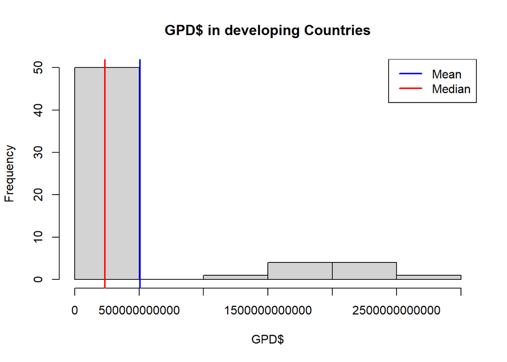

```r
#  histogram with mean, median
hist(developing_countries$GDP_US., breaks = 8, main = "GPD$ in developing Countries",
     xlab = "GPD$", ylab = "Frequency")
abline(v = mean(developing_countries$GDP_US.), col = "blue", lwd = 2)
abline(v = median(developing_countries$GDP_US.), col = "red", lwd = 2)
legend("topright", legend = c("Mean", "Median"), col = c("blue", "red"), lwd = 2)
```

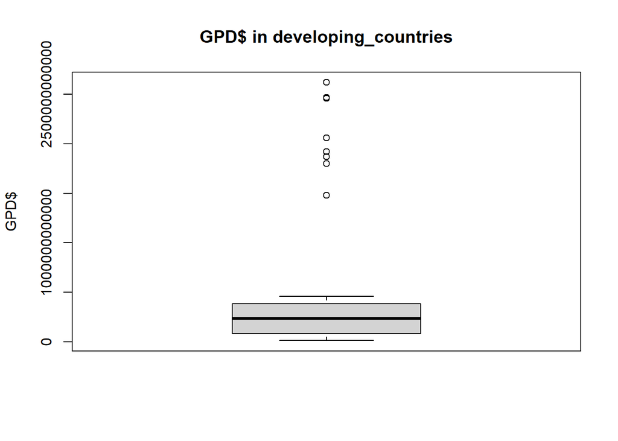

```r
#  boxplot
boxplot(developing_countries$GDP_US., main = "GPD$ in developing_countries",
        ylab = "GPD$")
```

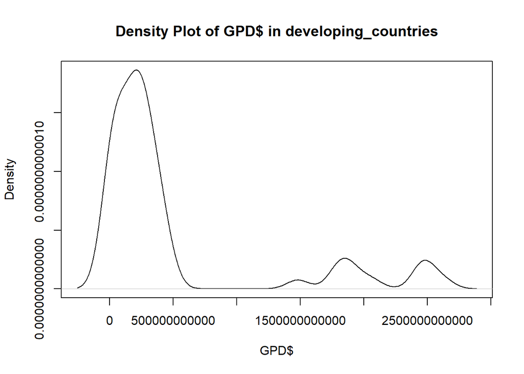

```r
# Create a density plot

plot(density(developing_countries$GDP_US.), main = "Density Plot of GPD$ in developing_countries",
     xlab = "GPD$", ylab = "Density")
```

These statistics describe the GDP distribution in developing countries. The mean GDP is higher than the median, which indicates that there might be some outliers as we can see from the boxplot or high GDP values pulling the mean up. The positive skewness suggests that the distribution is skewed towards higher GDP values, while the positive kurtosis indicates that the distribution has heavier tails and is more peaked compared to a normal distribution.

**developed country stats GPD**

```r
print('developed countries stat for GPD')
```

```
## [1] "developed countries stat for GPD"
```

```r
print(paste('mean in GPS$',mean(developed_countries$GDP_US.)))
```

```
## [1] "mean in GPS$ 1019616666666.67"
```

```r
print(paste('median in  GPS$',median(developed_countries$GDP_US.)))
```

```
## [1] "median in  GPS$ 868000000000"
```

```r
print(paste('mode in GPS$', mean(as.numeric(names(sort(table(developed_countries$GDP_US.), decreasing = TRUE)[1])))))
```

```
## [1] "mode in GPS$ 213000000000"
```

```r
print(paste('standars dev ',sd(developed_countries$GDP_US.)))
```

```
## [1] "standars dev  736718148429.906"
```

```r
print(paste("Skewness:", skewness(developed_countries$GDP_US.)))
```

```
## [1] "Skewness: 0.183005942904856"
```

```r
print(paste("Kurtosis:", kurtosis(developed_countries$GDP_US.)))
```

```
## [1] "Kurtosis: -1.70117220643362"
```

*visualize*

[figure not shown]

```r
#  histogram with mean, median
hist(developed_countries$GDP_US., breaks = 8, main = "GPD$ in developed_countries",
     xlab = "GPD$", ylab = "Frequency")
abline(v = mean(developed_countries$GDP_US.), col = "blue", lwd = 2)
abline(v = median(developed_countries$Life_expectancy_at_birth), col = "red", lwd = 2)
legend("topright", legend = c("Mean", "Median"), col = c("blue", "red"), lwd = 2)
```

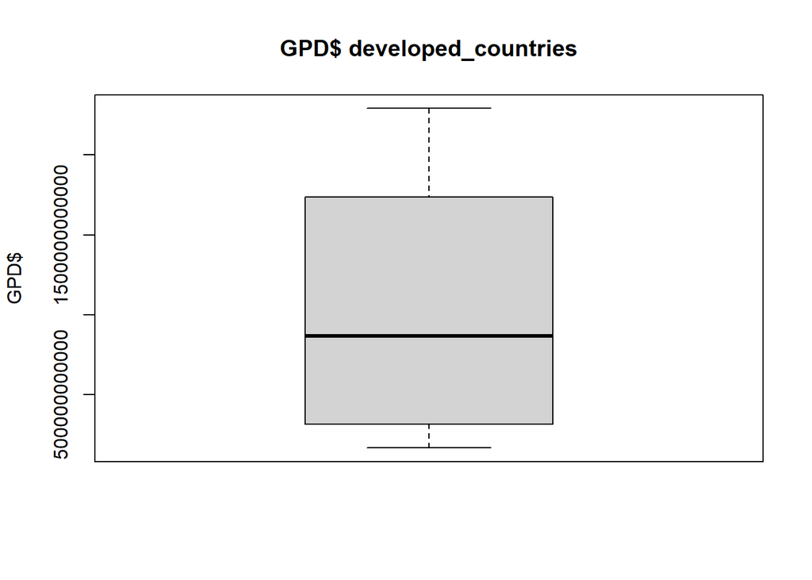

```r
#  boxplot
boxplot(developed_countries$GDP_US., main = "GPD$ developed_countries",
        ylab = "GPD$")
```

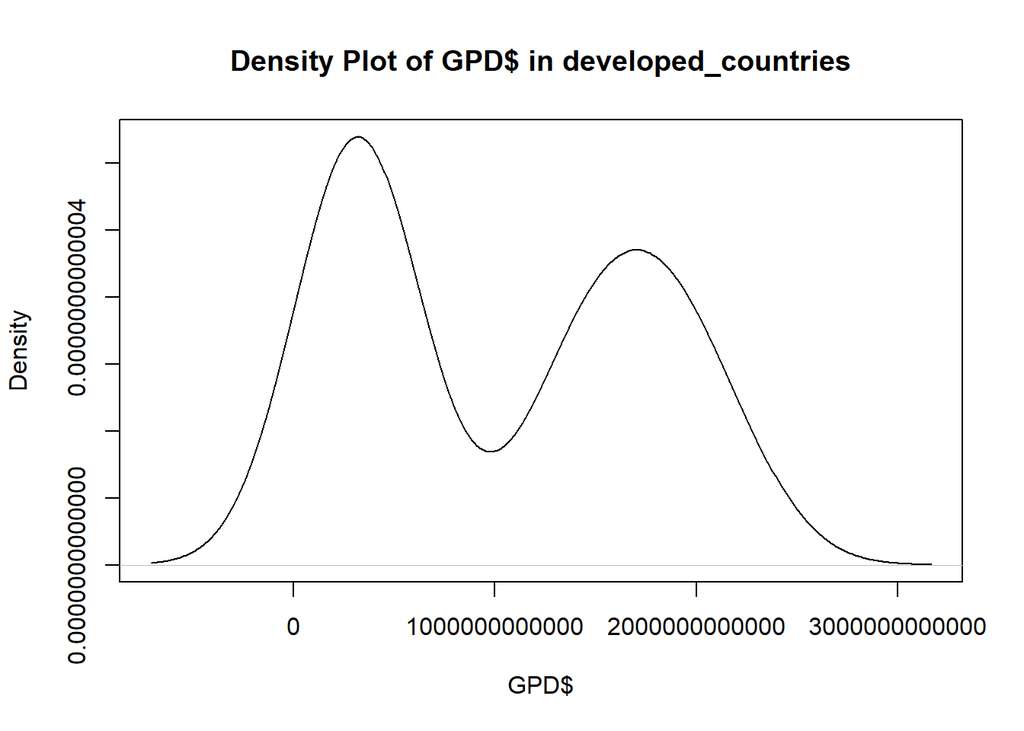

```r
# Create a density plot
plot(density(developed_countries$GDP_US.), main = "Density Plot of GPD$ in developed_countries",
     xlab = "GPD$", ylab = "Density")
```

Skewness is 0.1830, indicating a slight positive skew, meaning the distribution is slightly skewed to the right. Kurtosis is -1.7012, suggesting that the distribution has lighter tails and is flatter compared to a normal distribution. Negative kurtosis show a distribution with fewer extreme values. The mean GDP is higher than the median, suggesting that there might be a few countries with very high GDP values that pull the mean upwards. The positive skewness indicates a minor skew toward higher GDP values. It looks like that there are not outliers.

I will now do some statistics about developing country and developed country including Mean, Median, Mode,Standard deviation, Skewness and Kurtosis) on **Life expectancy.**

*developing countries:*

```r
print('developing countries stat for life expectancy')
```

```
## [1] "developing countries stat for life expectancy"
```

```r
print(paste('mean in life expectancy',mean(developing_countries$Life_expectancy_at_birth)))
```

```
## [1] "mean in life expectancy 69.7283833333333"
```

```r
print(paste('median in life expectancy',median(developing_countries$Life_expectancy_at_birth)))
```

```
## [1] "median in life expectancy 69.759"
```

```r
print(paste('mode in life expectancy', mean(as.numeric(names(sort(table(developing_countries$Life_expectancy_at_birth), decreasing = TRUE)[1])))))
```

```
## [1] "mode in life expectancy 57.596"
```

```r
print(paste('standars dev in life expectancy',sd(developing_countries$Life_expectancy_at_birth)))
```

```
## [1] "standars dev in life expectancy 7.14166682839889"
```

```r
print(paste("Skewness:", skewness(developing_countries$Life_expectancy_at_birth)))
```

```
## [1] "Skewness: 0.0224091880304791"
```

```r
print(paste("Kurtosis:", kurtosis(developing_countries$Life_expectancy_at_birth)))
```

```
## [1] "Kurtosis: -1.56466108710053"
```

here some visualization:

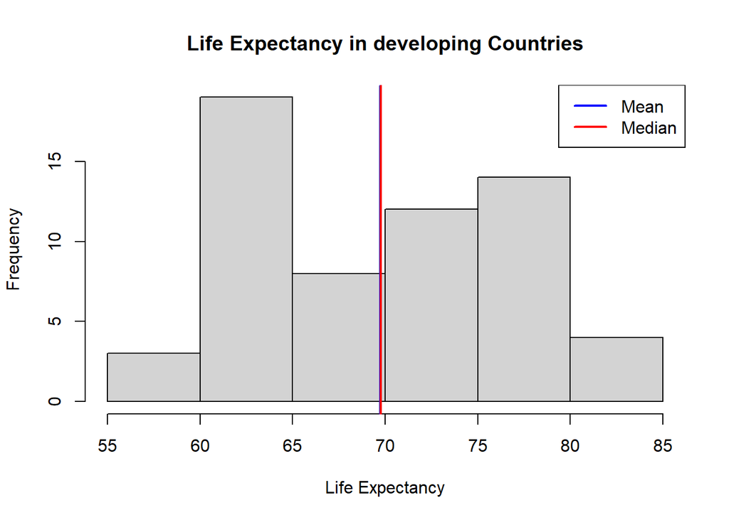

```r
#  histogram with mean, median
hist(developing_countries$Life_expectancy_at_birth, breaks = , main = "Life Expectancy in developing Countries",
     xlab = "Life Expectancy", ylab = "Frequency")
abline(v = mean(developing_countries$Life_expectancy_at_birth), col = "blue", lwd = 2)
abline(v = median(developing_countries$Life_expectancy_at_birth), col = "red", lwd = 2)
legend("topright", legend = c("Mean", "Median"), col = c("blue", "red"), lwd = 2)
```

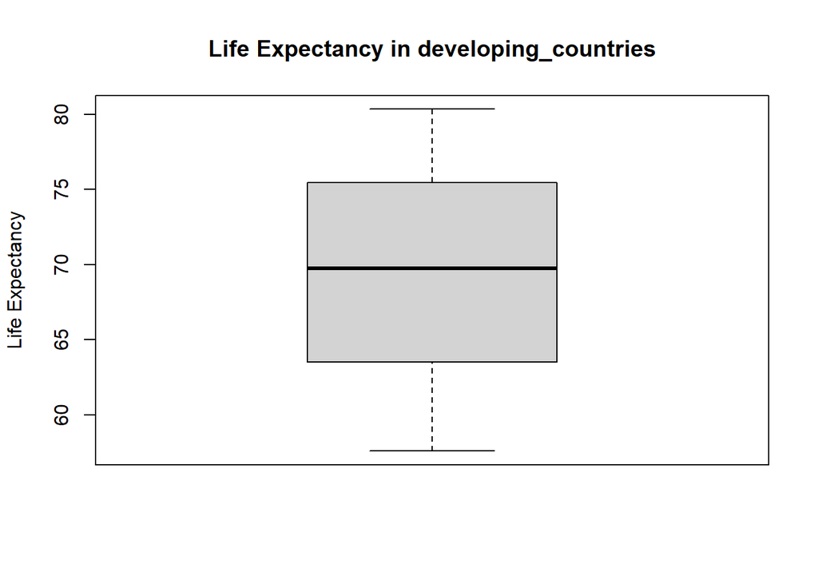

```r
#  boxplot
boxplot(developing_countries$Life_expectancy_at_birth, main = "Life Expectancy in developing_countries",
        ylab = "Life Expectancy")
```

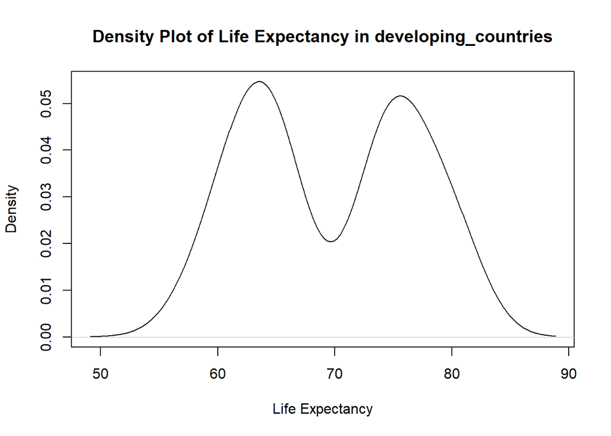

```r
# Create a density plot

plot(density(developing_countries$Life_expectancy_at_birth), main = "Density Plot of Life Expectancy in developing_countries",
     xlab = "Life Expectancy", ylab = "Density")
```

with the stat we did we can say that the life expectancy in developing countries is centered around 69.73 years (mean), with a slightly right-skewed distribution.(“Skewness: 0.0224091880304791”) meaning that it has a slightly longer right tail, also that more data points have life expectancy values slightly above the mean. The distribution is relatively flat and less peaked compared to a normal distribution There are not significnt outliers

*same stat for the most developed country:*

```r
print('developed_countries stat for life expectancy')
```

```
## [1] "developed_countries stat for life expectancy"
```

```r
print(paste('mean in life expectancy',mean(developed_countries$Life_expectancy_at_birth)))
```

```
## [1] "mean in life expectancy 82.3084227643333"
```

```r
print(paste('median in life expectancy',median(developed_countries$Life_expectancy_at_birth)))
```

```
## [1] "median in life expectancy 82.23390244"
```

```r
print(paste('mode in life expectancy', as.numeric(names(sort(table(developed_countries$Life_expectancy_at_birth), decreasing = TRUE)[1]))))
```

```
## [1] "mode in life expectancy 81.15609756"
```

```r
print(paste('standars dev in life expectancy',sd(developed_countries$Life_expectancy_at_birth)))
```

```
## [1] "standars dev in life expectancy 0.675674524053387"
```

```r
print(paste("Skewness:", skewness(developed_countries$Life_expectancy_at_birth)))
```

```
## [1] "Skewness: 0.6442372113454"
```

```r
print(paste("Kurtosis:", kurtosis(developed_countries$Life_expectancy_at_birth)))
```

```
## [1] "Kurtosis: 0.137658651648029"
```

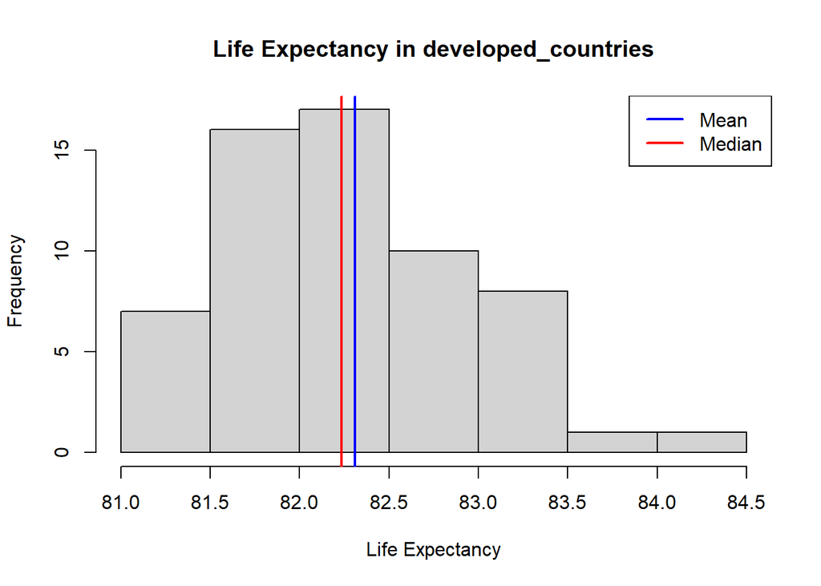

```r
#  histogram with mean, median
hist(developed_countries$Life_expectancy_at_birth, breaks = 8, main = "Life Expectancy in developed_countries",
     xlab = "Life Expectancy", ylab = "Frequency")
abline(v = mean(developed_countries$Life_expectancy_at_birth), col = "blue", lwd = 2)
abline(v = median(developed_countries$Life_expectancy_at_birth), col = "red", lwd = 2)
legend("topright", legend = c("Mean", "Median"), col = c("blue", "red"), lwd = 2)
```

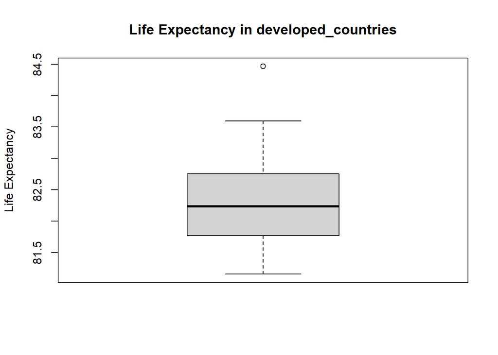

```r
#  boxplot
boxplot(developed_countries$Life_expectancy_at_birth, main = "Life Expectancy in developed_countries",
        ylab = "Life Expectancy")
```

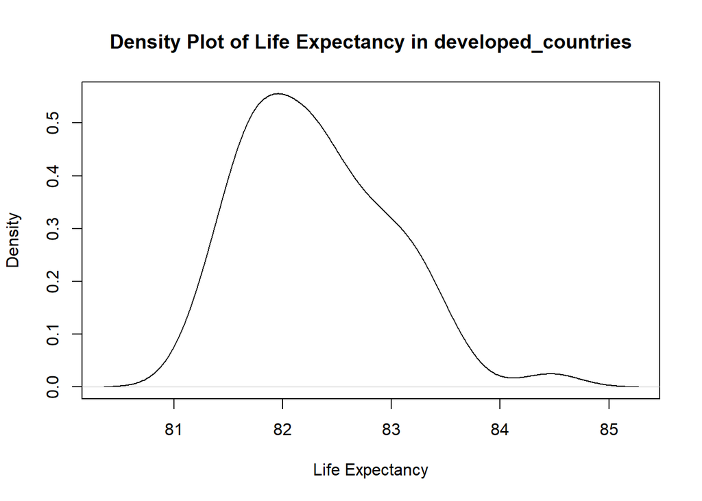

```r
# Create a density plot
plot(density(developed_countries$Life_expectancy_at_birth), main = "Density Plot of Life Expectancy in developed_countries",
     xlab = "Life Expectancy", ylab = "Density")
```

with the stat we did we can say that the life expectancy in developed countries is centered around 82.31 years (mean), with a slightly right-skewed distribution. The distribution is slightly more peaked (leptokurtic) compared to a normal distribution, suggesting that life expectancy values may have slightly more extreme values and are slightly more concentrated around the mean(standard dev infact is very low. There is some otliers but notting to worry about at least for now.

**part 2** **Examine the relationship between GDP and life expectancy of the countries taken in consideration from the 2 groups (developed and developing country).Also extend the reaserch between the least developed and most developed country of the 2 groups(correlation) Construct a correlation matrix for all variables to identify potential associations.**

*correlation between developed/deceloping countries* first we need to check the assumption: linearity data is normaly distributed

*linearity*

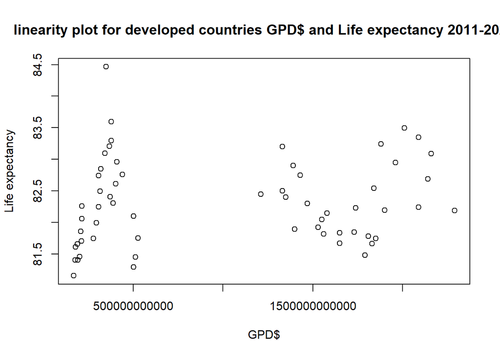

```r
#check for linearity
plot(developed_countries$GDP_US.,developed_countries$Life_expectancy_at_birth,
     xlab = 'GPD$',
     ylab = 'Life expectancy',
     main = 'linearity plot for developed countries GPD$ and Life expectancy 2011-2020')
```

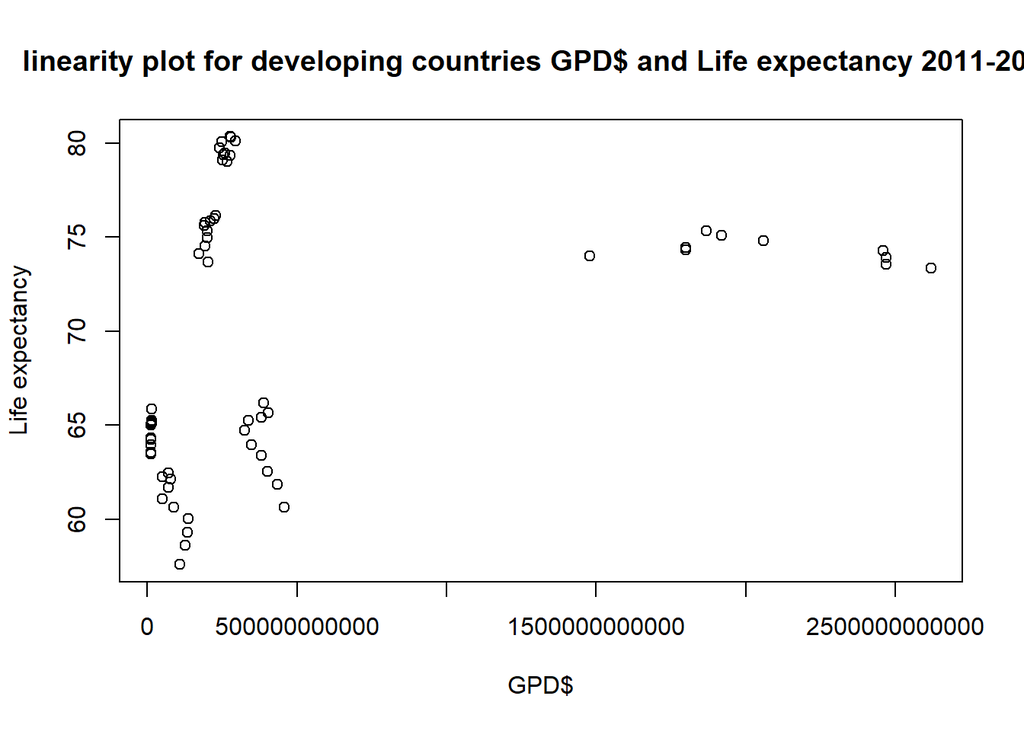

```r
plot(developing_countries$GDP_US.,developing_countries$Life_expectancy_at_birth,
     xlab = 'GPD$',
     ylab = 'Life expectancy',
     main = 'linearity plot for developing countries GPD$ and Life expectancy 2011-2020')
```

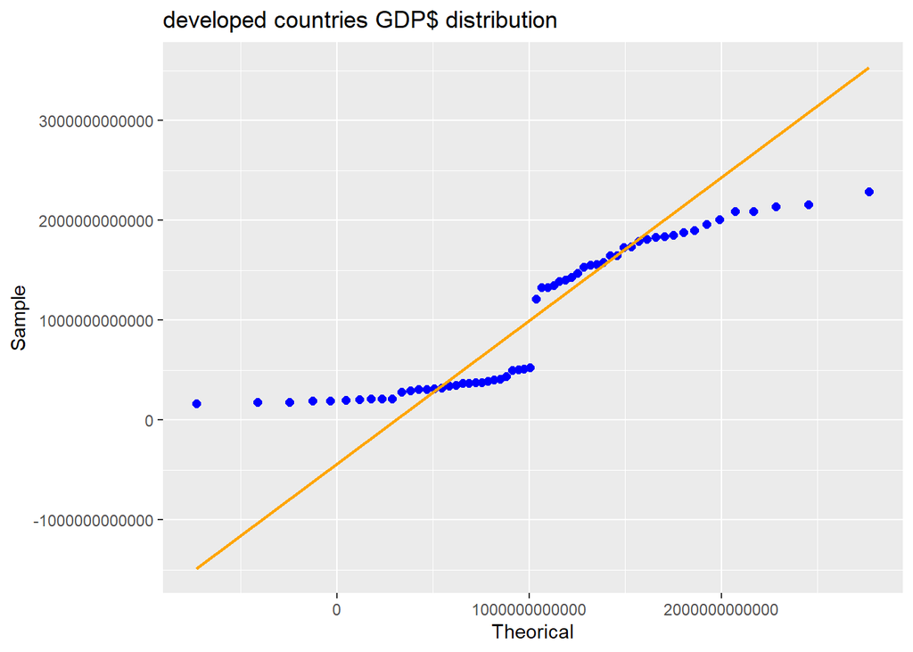

```r
#check for distribution

ggplot(mapping=aes(sample=developed_countries$GDP_US.))+
  stat_qq_point(size=2,color='blue')+
  stat_qq_line(color='orange')+
  xlab('Theorical')+
  ylab('Sample')+
  ggtitle('developed countries GDP$ distribution')
```

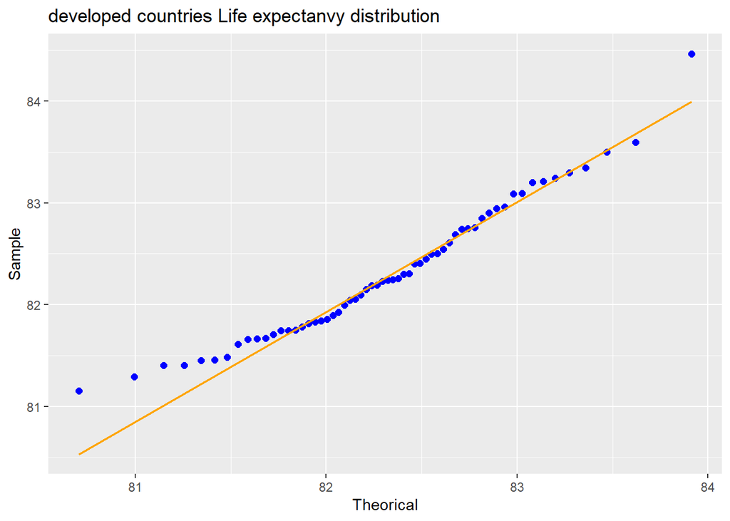

```r
ggplot(mapping=aes(sample=developed_countries$Life_expectancy_at_birth))+
  stat_qq_point(size=2,color='blue')+
  stat_qq_line(color='orange')+
  xlab('Theorical')+
  ylab('Sample')+
  ggtitle('developed countries Life expectanvy distribution')
```

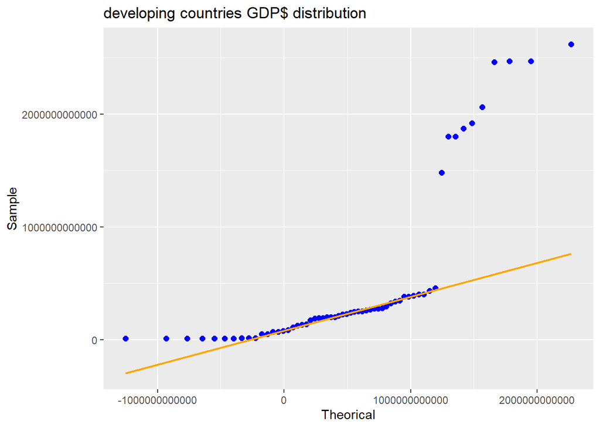

```r
ggplot(mapping=aes(sample=developing_countries$GDP_US.))+
  stat_qq_point(size=2,color='blue')+
  stat_qq_line(color='orange')+
  xlab('Theorical')+
  ylab('Sample')+
  ggtitle('developing countries GDP$ distribution')
```

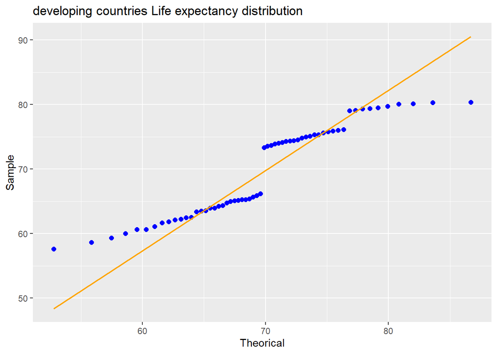

```r
  ggplot(mapping=aes(sample=developing_countries$Life_expectancy_at_birth))+
  stat_qq_point(size=2,color='blue')+
  stat_qq_line(color='orange')+
  xlab('Theorical')+
  ylab('Sample')+
  ggtitle('developing countries Life expectancy distribution')
```

```r
  shapiro.test(developed_countries$GDP_US.)
```

```
##
##  Shapiro-Wilk normality test
##
## data:  developed_countries$GDP_US.
## W = 0.83978927782552204, p-value = 0.0000015422975026829157
```

```r
  shapiro.test(developed_countries$Life_expectancy_at_birth)
```

```
##
##  Shapiro-Wilk normality test
##
## data:  developed_countries$Life_expectancy_at_birth
## W = 0.962598421342626409, p-value = 0.063084764424234815
```

```r
  shapiro.test(developing_countries$GDP_US.)
```

```
##
##  Shapiro-Wilk normality test
##
## data:  developing_countries$GDP_US.
## W = 0.629108648805886794, p-value = 0.000000000047580758551165574
```

```r
  shapiro.test(developing_countries$GDP_US.)
```

```
##
##  Shapiro-Wilk normality test
##
## data:  developing_countries$GDP_US.
## W = 0.629108648805886794, p-value = 0.000000000047580758551165574
```

```r
shapiro.test(log(developed_countries$GDP_US.))
```

```
##
##  Shapiro-Wilk normality test
##
## data:  log(developed_countries$GDP_US.)
## W = 0.852731059682080739, p-value = 0.0000036705497693075529
```

```r
shapiro.test(sqrt(developed_countries$GDP_US.))
```

```
##
##  Shapiro-Wilk normality test
##
## data:  sqrt(developed_countries$GDP_US.)
## W = 0.846060258427453804, p-value = 0.0000023355744011566108
```

```r
shapiro.test(developed_countries$GDP_US.^(1/3)) #cube root transformation
```

```
##
##  Shapiro-Wilk normality test
##
## data:  developed_countries$GDP_US.^(1/3)
## W = 0.848556878822784855, p-value = 0.0000027625102104801222
```

```r
cor(developed_countries$GDP_US.,developed_countries$Life_expectancy_at_birth,method = 'spearman')
```

```
## [1] 0.24533859534494126264
```

```r
cor(developing_countries$GDP_US.,developed_countries$Life_expectancy_at_birth,method='spearman')
```

```
## [1] -0.14135267333154236113
```

from this 2 correlation test we can see that there is a weak positive correlation between developed countries GDP$ and life expectancy, thus when one increase the other one tend to increase too.keep in mind that the relation is very weak.

**It’s important to note that Spearman correlation measures the strength and direction of monotonic relationships, which are non-linear but consistently increasing or decreasing relationships. These coefficients are between -1 and 1, with -1 indicating a perfect negative monotonic relationship, 1 indicating a perfect positive monotonic relationship, and 0 indicating no monotonic relationship.**

*Another important think that we need to remember is that:Also correlation does not imply causation. A significant correlation only indicates that two variables are related but doesn’t provide information about the direction or causality of the relationship.

*Let’s now analyse some correlation between the same factors but between the least developed country and the most developed country:* define the countries:

```r
Madagascar <- data %>%
  filter(Country_Name == 'Madagascar') %>%
  group_by( Time)
Madagascar=as.data.frame(Madagascar)

Norway <- data %>%
  filter(Country_Name == 'Norway') %>%
  group_by( Time)
Norway=as.data.frame(Norway)
```

check for assumptions:

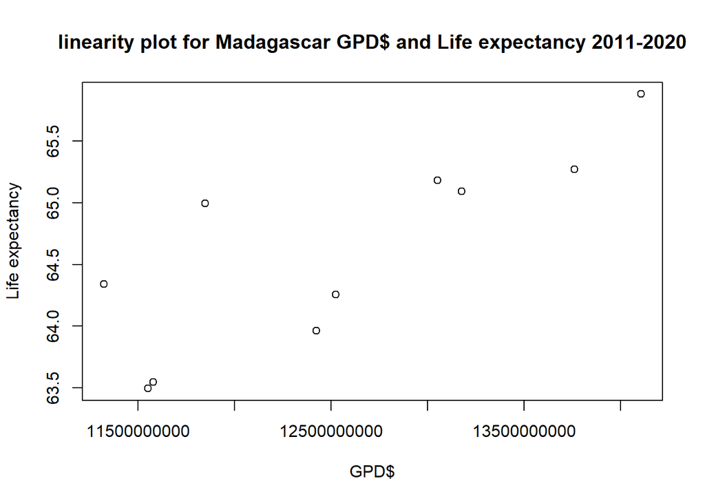

```r
#check for linearity
plot(Madagascar$GDP_US.,Madagascar$Life_expectancy_at_birth,
     xlab = 'GPD$',
     ylab = 'Life expectancy',
     main = 'linearity plot for Madagascar GPD$ and Life expectancy 2011-2020')
```

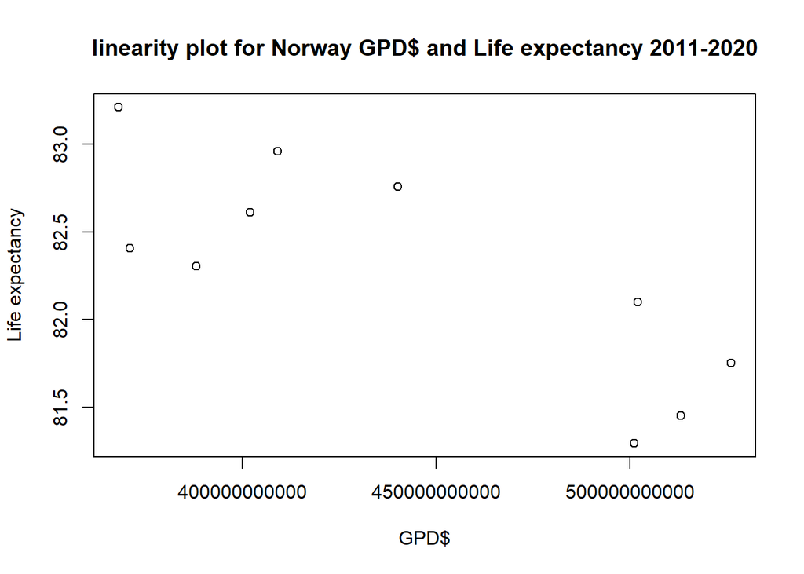

```r
plot(Norway$GDP_US.,Norway$Life_expectancy_at_birth,
     xlab = 'GPD$',
     ylab = 'Life expectancy',
     main = 'linearity plot for Norway GPD$ and Life expectancy 2011-2020')
```

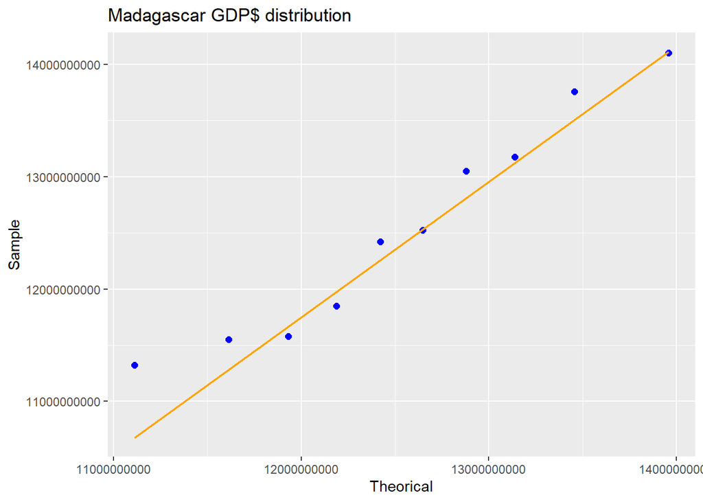

```r
#check for distribution

ggplot(mapping=aes(sample=Madagascar$GDP_US.))+
  stat_qq_point(size=2,color='blue')+
  stat_qq_line(color='orange')+
  xlab('Theorical')+
  ylab('Sample')+
  ggtitle('Madagascar GDP$ distribution')
```